[figure not shown]

[figure not shown]

# SUPPLEMENT: 2022 Update to Data Brief on 2020-2021 Increases in Deaths in California

California Department of Public Health - Fusion Center - Last updated: 8.18.2023

This document is a supplement to “[Data Brief: 2020 and 2021 Increases in Deaths in California (7.1.2022)](https://skylab.cdph.ca.gov/communityBurden/_w_d2166d19/xMDA/2020_Excess_Mortality.html)”, and provides an update with data through 2022. The charts and tables below are through 2022 with text focusing on observations pertinent to 2022. Please see the original Data Brief for an overall summary, comments on 2020 and 2021 observations, detailed methods, conclusions, and a section of exploratory material.

# Summary

New observations based on 2022 excess mortality data include:

- In 2022, the number of deaths and age-adjusted death rates remained higher than the prepandemic baseline of 2019, but *decreased* relative to 2021.
- In Quarter 1 of 2022, the *increase* in death rate (compared to the 2017-2019 mean baseline) exceeded 20% among Native Hawaiian and Pacific Islanders, Latinos, and American Indian/Alaska Natives.
- Very substantial increases in death rates were seen in conditions other than COVID-19, including drug overdoses, obesity, homicide, and malnutrition. Increase of *over 20%* were seen for all these conditions in 2022 compared to the prepandemic baseline.

# Findings

## Deaths were higher in 2020, 2021 and 2022 compared to 2019

### **Table 1 - Number, Age-Adjusted Rate, and Increase in Rate from Prior Year, Deaths from All Causes in California, 2017-2022**

- In 2022 there were 309,782 deaths in California (corresponding to an age-adjusted all-cause death rate of 624.8 per 100,000 population), a decrease of -9.0% from 2021.

| Year | Number of Deaths | Age-Adjusted Death Rate | % Increase in Rate from Prior Year |
| --- | --- | --- | --- |
| 2022 | 309782 | 624.819 | -0.0899253959607201 |
| 2021 | 329967 | 686.558 | 0.0155672643683602 |
| 2020 | 317259 | 676.034 | 0.158288628953361 |
| 2019 | 267301 | 583.649 | -0.0231227320809288 |
| 2018 | 266517 | 597.464 | -0.0190568915610823 |
| 2017 | 265721 | 609.071 |  |

### **Figure 1 - All-Cause Death Rate by Quarter and Year, California 2017-2022**

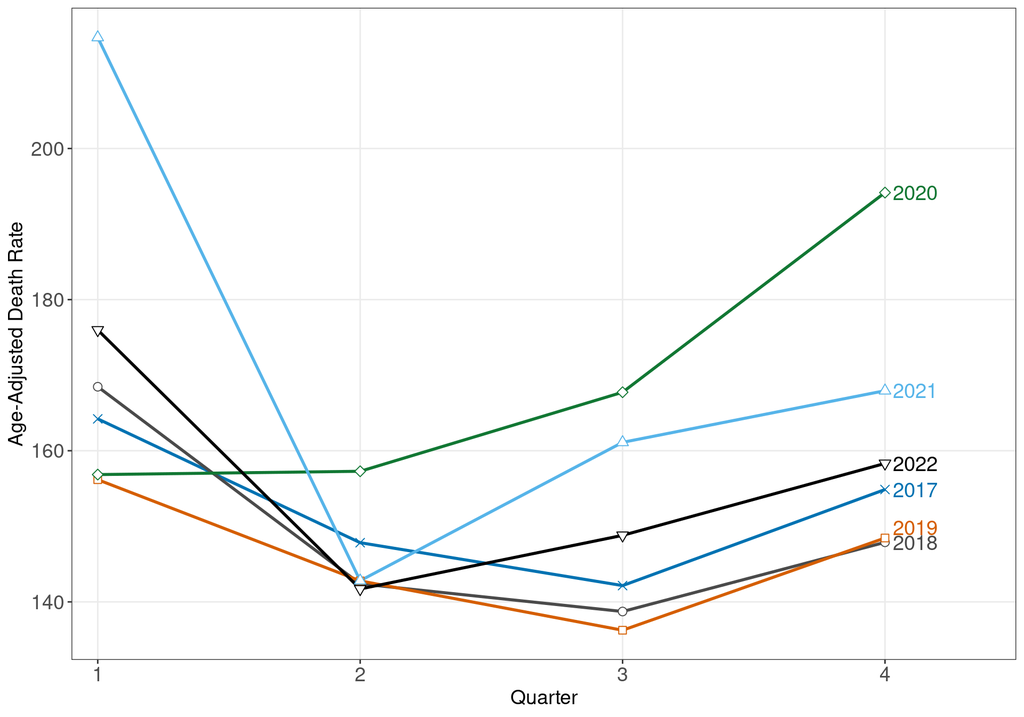

## Deaths increased more among some race/ethnicity groups than others

### **Figure 2 - Percentage Increase in Race-Specific Age-Adjusted Death Rates 2019 to 2020/2021/2022**

- In 2022, the *increase* in death rate compared to the prepandemic baseline was lowest among Whites (2.8%) and ranged between 8% and 14% among the other racial/ethnic groups.

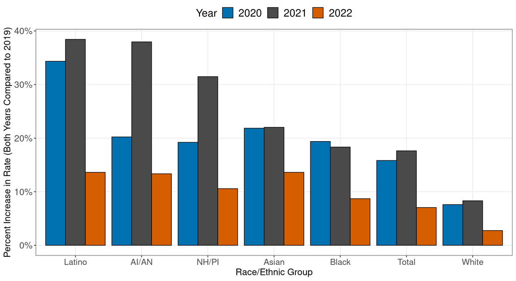

### **Figure 3a - Trends in All Cause Age-Adjusted Mortality Rate by Race/Ethnicity by Quarter, 2020/2021/2022 and 2017-2019 Average**

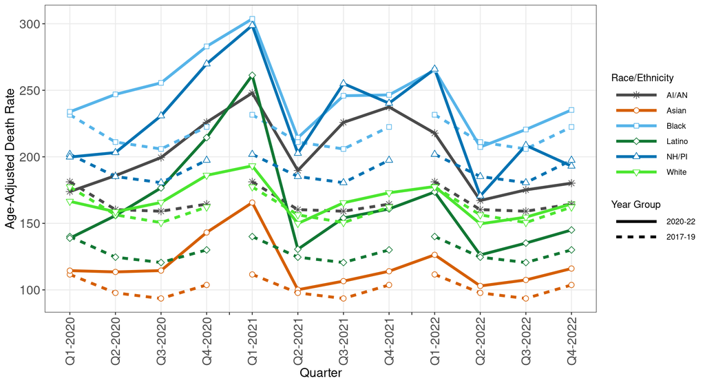

### **Figure 3b - Percentage Increase in Age-Adjusted Death Rate by Quarter, 2020/2021/2022 and 2017-2019 Average, by Race/Ethnicity**

- Reflecting the patterns above, with only a few exceptions, increases in 2022 for all racial/ethnic groups were smaller than the corresponding increases in 2020 and 2021.
- However, there was a large increase among NH/PI (31.7%) in Quarter 1 of 2022 compared to the baseline.
- Death rates *decreased* in Quarter 2 among Blacks (-1.8%), Native Hawaiian and Pacific Islanders (-7.9%), and Whites (-4.3%), and in Quarter 4 among Native Hawaiian and Pacific Islanders (-2.2%).

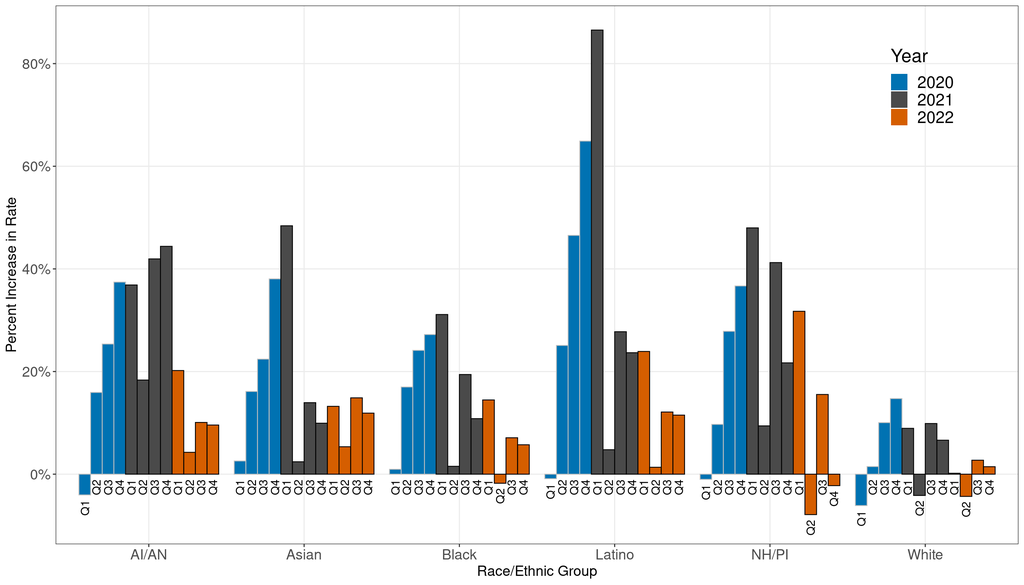

## Causes of death other than COVID-19 also increased

### **Table 2 - 2017 to 2022, Selected Causes of Death, ordered by percent increase 2019 to 2022 [note: table is sortable]**

- Compared to 2019, increases in death rates of *over 25%* were seen for drug overdoses, malnutrition, obesity, homicide, and alcohol-related in 2022.
- Compared to 2019, the absolute number of deaths increased by over 1,000 for Alzheimer’s disease, drug overdoses, ischemic heart disease, hypertensive heart disease, stroke, kidney diseases, alcohol-related, and diabetes in 2022.
- Compared to 2019, deaths caused by hepatitis, COPD, pneumonia, influenza, lung cancer, and valve disorders all *decreased* by more than 10% in 2022.

[interactive table not shown]

##### Note: The criteria for inclusion in **Table 2** changed from the original Data Brief. The data were first restricted to causes of death for which there were > 500 deaths in any year, 2017-2022. Then, among those causes, the data were restricted to causes that had among the top five relative (percent change in age-adjusted death rate) or absolute (change in number of deaths) increases, or among the bottom three relative or absolute decreases from 2019 to 2020, 2021, or 2022.

### **Figure 4 - Trends in Age-Adjusted Rates for Selected Causes of Death (log-y-axis), 2010-2022**

- Figure 4 below shows the trend from 2010 to 2022 of annual death rates for the causes with large increases noted above, and other selected leading causes of death.
- Deaths from COVID-19 decreased sharply between 2021 and 2022, falling from the leading cause of death to the fourth leading.
- Other notable 2022 trends include an encouraging leveling off of drug overdose deaths, and decreases in alcohol-related deaths and homicides.

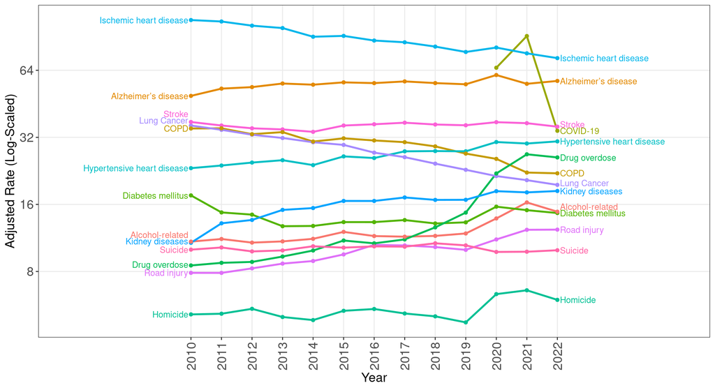

## The amount of increase in deaths, and conditions associated with the increase, differed substantially by age and race/ethnicity

### **Figure 5 - Percent Increase in Number of Deaths 2019 to 2020/2021/2022 by Age Group and Race/Ethnicity and Proportion of Increase due to COVID-19**

- Compared to the increases described previously for 2020 and 2021, many of the age and race/ethnicity specific changes are attenuated in 2022. For example, and possibly of particular note, the increase in deaths among Blacks ages 5-14 was much lower in 2022 than in prior years. While COVID-19 caused less deaths in 2022 compared to 2020 and 2021, it still led to increases in deaths of more than 20% from 2019 to 2022 among AI/AN 35-44 and 55-84, Asians 35-44 and 65-74, Latinos 25-84, and NH/PI 25-64 and 75-84.

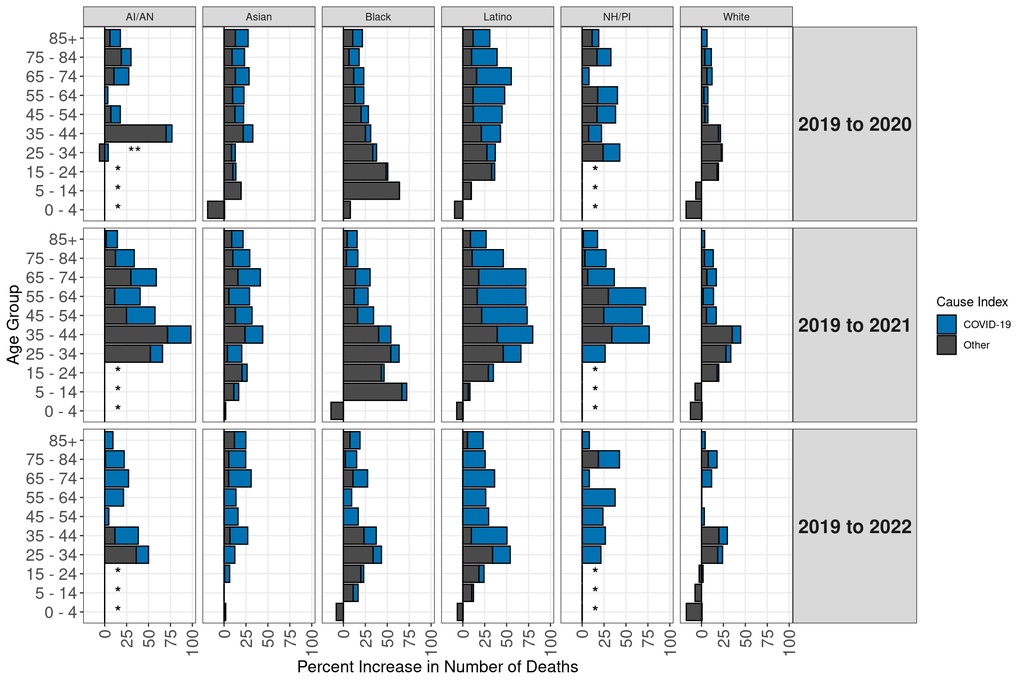

##### *For younger NH/PI and AI/AN age groups, the underlying number of deaths for 2019 and 2020, 2021 or 2022 is <25 so data are not shown

##### **25-34 year old AI/AN experienced an overall decrease in deaths, and had a small number of deaths from COVID-19

# Links to related information

### National excess mortality

- [COVID-19 is the Number One Cause of Death in the U.S. in Early 2021 (Kaiser Family Foundation Data - 2.22.2021)](https://www.healthsystemtracker.org/brief/covid-19-is-the-number-one-cause-of-death-in-the-u-s-in-early-2021/)
- [Leading Causes of Death in the US for 2020 (National Center for Health Statistics - JAMA - 3.31.2021)](https://jamanetwork.com/journals/jama/fullarticle/2778234)
- [Excess Deaths From COVID-19 and Other Causes in the US (JAMA - 4.2.2021)](https://jamanetwork.com/journals/jama/fullarticle/2778361)
- [Learning From Excess Pandemic Deaths - Editorial related to article above (JAMA 4.2.2021)](https://jamanetwork.com/journals/jama/fullarticle/2778362)
- [Excess Deaths Associated with COVID-19 (CDC Dashboard)](https://www.cdc.gov/nchs/nvss/vsrr/covid19/excess_deaths.htm)

### California excess mortality

- [Excess Mortality in California During the Coronavirus Disease 2019 Pandemic, March to August 2020 (UCSF team - JAMA Internal Medicine research letter 5.2021)](https://jamanetwork.com/journals/jamainternalmedicine/fullarticle/2774273)
- [COVID-19 mortality in California based on death certificates: disproportionate impacts across racial/ethnic groups and nativity (USC Team - Annals of Epidemiology June 2021)](https://www.sciencedirect.com/science/article/pii/S1047279721000430)
- [40,000+ excess deaths in 2020, and other things we learned from California death data (The Mercury News 1.27.2021)](https://www.mercurynews.com/2021/01/27/40000-excess-deaths-in-2020-and-other-things-we-learned-from-california-death-data/)

### California excess mortality - occupational sector

- [Excess mortality associated with the COVID-19 pandemic among Californians 18–65 years of age, by occupational sector and occupation - UCSF team (PLOS ONE 6.4.2021)](https://journals.plos.org/plosone/article?id=10.1371/journal.pone.0252454)
- [Pandemic’s Toll on California Workers in High Risk Industries (UC Merced Fact Sheet 4.2021)](https://clc.ucmerced.edu/sites/clc.ucmerced.edu/files/page/documents/fact_sheet_-_the_pandemics_toll_on_california_workers_in_high_risk_industries.pdf) and [related newsletter](https://www.universityofcalifornia.edu/news/analysis-shows-toll-pandemic-high-risk-workers)